# Reproducible Research: Peer Assessment 1

Leonardo Sanna

## Loading and preprocessing the data

The following code download our data

```r
library(dplyr)
```

```r
library(ggplot2)
library(data.table)
data_source <- "https://d396qusza40orc.cloudfront.net/repdata%2Fdata%2Factivity.zip"
file <- "Factivity.zip"
download.file(data_source, destfile = file)
dataset <- unzip(file)
str(dataset)
```

```
##  chr "./activity.csv"
```

```r
activity <- read.csv("activity.csv", header = TRUE, fill= TRUE)
```

## What is mean total number of steps taken per day?

#### 1. Calculate the total number of steps taken per day

```r
steps_per_day <- activity %>%
        group_by(date) %>%
        summarize(tot_steps = sum(steps, na.rm = TRUE))
```

#### 2. Make a histogram of the total number of steps taken each day

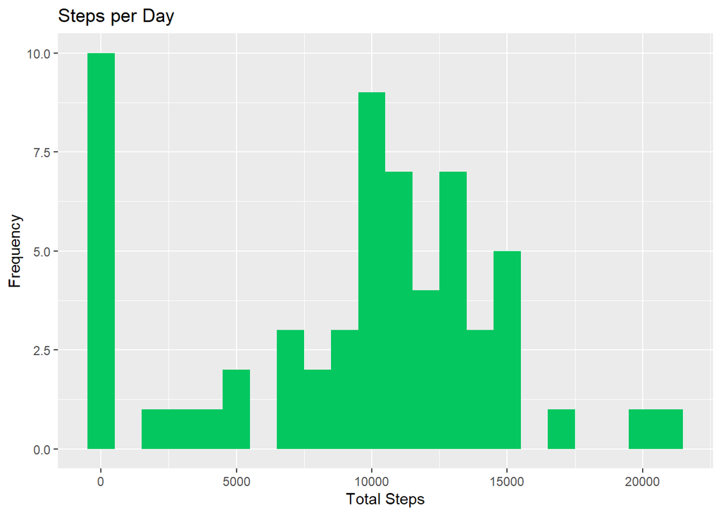

```r
ggplot(steps_per_day, aes(x = tot_steps)) +
        geom_histogram(fill = "#05c760", binwidth = 1000) +
        labs(title = "Steps per Day", x = "Total Steps", y = "Frequency")
```

#### 3. Calculate and report the mean and median of the total number of steps taken per day

```r
summary(steps_per_day$tot_steps)
```

```
##    Min. 1st Qu.  Median    Mean 3rd Qu.    Max.
##       0    6778   10395    9354   12811   21194
```

## What is the average daily activity pattern?

#### Make a time series plot (i.e. 𝚝𝚢𝚙𝚎 = “𝚕”) of the 5-minute interval (x-axis) and the average number of steps taken, averaged across all days (y-axis)

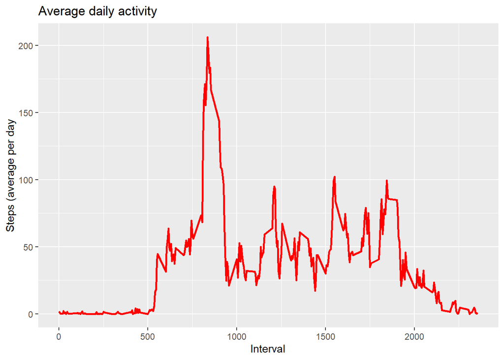

```r
daily_activity <- activity %>%
        group_by(interval) %>%
        summarize(mean_steps = mean(steps, na.rm = TRUE))

ggplot(daily_activity, aes(x = interval, y = mean_steps)) +
        geom_line(color = "red", size = 1) +
        labs(title = "Average daily activity", x = "Interval", y = "Steps (average per day")
```

#### 1. Which 5-minute interval, on average across all the days in the dataset, contains the maximum number of steps?

```r
daily_activity %>%
select(mean_steps, interval) %>%
filter(mean_steps == max(mean_steps, na.rm = TRUE)) %>%
print
```

```
## # A tibble: 1 x 2
##   mean_steps interval
##        <dbl>    <int>
## 1       206.      835
```

## Imputing missing values

```r
nrow(is.na(activity))
```

```
## [1] 17568
```

#### 2. Devise a strategy for filling in all of the missing values in the dataset

```r
clean_activity <- numeric(nrow(activity))
for (i in 1:nrow(activity))
{
        if (is.na(activity[i,"steps"])==TRUE)
        {
                clean_activity[i]<-filter(daily_activity,
                interval==activity[i,"interval"]) %>% select(mean_steps)
        }
        else
        {
                clean_activity[i]<-activity[i,"steps"]
        }

}
```

#### 3. Create a new dataset that is equal to the original dataset but with the missing data filled in.

```r
activity_clean_activity<-mutate(activity,  steps_clean=clean_activity)
head(activity_clean_activity)
```

```
##   steps       date interval steps_clean
## 1    NA 2012-10-01        0    1.716981
## 2    NA 2012-10-01        5   0.3396226
## 3    NA 2012-10-01       10   0.1320755
## 4    NA 2012-10-01       15   0.1509434
## 5    NA 2012-10-01       20   0.0754717
## 6    NA 2012-10-01       25     2.09434
```

#### 4. Make a histogram of the total number of steps taken each day and Calculate and report the mean and median total number of steps taken per day

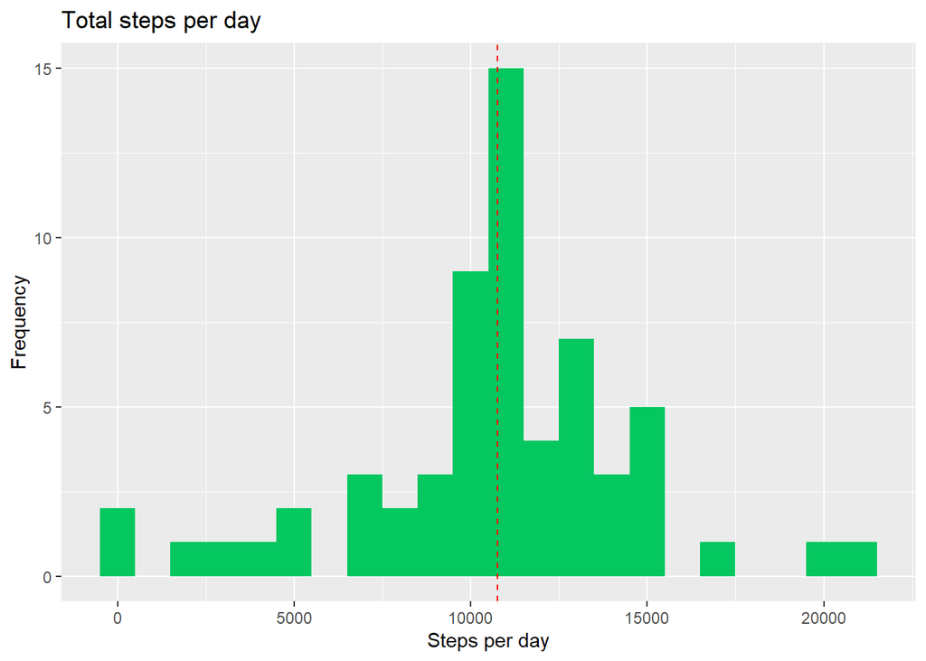

```r
total_clean <- activity_clean_activity %>%
        mutate(steps_clean=as.numeric(steps_clean)) %>%
        group_by(date) %>%
        summarise(tot_steps=sum(steps_clean))


ggplot(total_clean, aes(x = tot_steps)) +
        geom_histogram(fill = "#05c760", binwidth = 1000) +
        geom_vline(xintercept=median(total_clean$tot_steps),
                   linetype="dashed", color = "red") +
        labs(title = "Total steps per day", x = "Steps per day", y = "Frequency")
```

```r
summary(total_clean$tot_steps)
```

```
##    Min. 1st Qu.  Median    Mean 3rd Qu.    Max.
##      41    9819   10766   10766   12811   21194
```

## Are there differences in activity patterns between weekdays and weekends?

#### 1. Create a new factor variable in the dataset with two levels – “weekday” and “weekend” indicating whether a given date is a weekday or weekend day

```r
library(lubridate)
is_weekday <-function(date){
        if(wday(date)%in%c(1,7)) result<-"weekend"
        else
                result<-"weekday"
        result
}
activity_clean_activity <- mutate(activity_clean_activity,date=ymd(date)) %>% mutate(day=sapply(date,is_weekday))
table(activity_clean_activity$day)
```

```
##
## weekday weekend
##   12960    4608
```

#### 2. Make a panel plot containing a time series plot (i.e. type = “l”) of the 5-minute interval (x-axis) and the average number of steps taken, averaged across all weekday days or weekend days (y-axis)

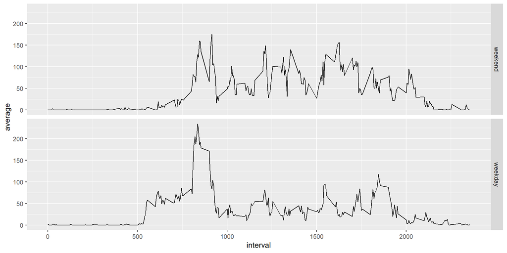

```r
daily_patterns <- activity_clean_activity %>%
        mutate(day=factor(day,levels=c("weekend","weekday")),
               steps=as.numeric(steps)) %>%
        group_by(interval,day) %>%
        summarise(average=mean(steps, na.rm = TRUE))

qplot(interval,average,data=daily_patterns,geom="line",facets=day~.)
```